# Introduction to

## Getting Started with PyMC3

### Why hasn't Bayesian Modeling been an industry-wide recommendation?

Similar to the growth of Machine Learning & Artificial Intelligence, Probabilistic Programming, implementation of Bayesian Modeling, had a combination of innovation & limitations due to the following:

- computationally challenging
- conceptually challenging to work
- Algorithms advancements like the [Metropolis](https://www.nytimes.com/2021/02/09/science/arianna-wright-dead.html) or [No-U-Turn](https://arxiv.org/abs/1111.4246) Sampler are more recently relevant to for the advancement of the field itself

However, as data technology has become more advanced in the recent years, we can now leverage the opportunity to implement Probabilistic Programming.

### What is PyMC3?

[figure not shown]

[PyMC3](https://pymc3.readthedocs.io/en/stable/) is a Python package for Bayesian statistical modeling and Probabilistic Machine Learning. It's associated to one of several Probabilistic Programming Languages (PPL) which focuses on advanced Markov chain Monte Carlo (MCMC) and variational fitting algorithms, and more.

Some features of PyMC3 are the following:

- Intuitive model specification syntax
- Leverage several (Sampling) Algorithms
  - [Hamiltonian Monte Carlo Markov Chain](https://en.wikipedia.org/wiki/Hamiltonian_Monte_Carlo)
  - No U-Turn Sampler ([NUTS](https://arxiv.org/abs/1111.4246))
  - Variational Inference
- Built on top of Theano
  - Theano features
  - Leverage dynamic C compilation for optimized computation
  - Automatic Differentiation

    > Note: As of 2021, Theano is now "Aesara". See ["The Future of PyMC3, or: Theano is Dead, Long Live Theano "](https://discourse.pymc.io/t/the-future-of-pymc3-or-theano-is-dead-long-live-theano/6159/2) for historical background & next steps
- [And more](https://docs.pymc.io/)!

### PyMC3 Example

Using the coin-toss example, let's say we have flip a coin 4 times.

We have some intuition that the probability from coin tosses are 0.35 and we have some idea of what the probability of the coin tosses would be.

We would like to see the probability of flipping the coin with our prior assumption and 4 attempts.

```
trials = 4

𝜃_real = 0.35
data = stats.bernoulli.rvs(p=𝜃_real, size =trials)
```

```
Trials:  4
Bias (𝜃):  0.35
Data:  [1 0 0 0]
```

To go about this, we would be leveraging PyMC3 in the following procedure:

1. Instantiate (model) Object
2. Inference
   - Calculate output distribution
3. Predict & Evaluate

#### 1. Instantiate Object

```
import pymc3 as pm

with pm.Model() as coin_flip_model:
    𝜃 = pm.Beta('𝜃', alpha=1, beta=1)
    y = pm.Bernoulli('y', p = 𝜃, observed=data)
```

#### 2.Inference

We now perform inference to approximate the posterior distribution.

The options for this inference is either by:

- sampling
- variational inference

```
with coin_flip_model:
    trace = pm.sample(2_000, random_seed=123, return_inferencedata=True)
```

```
Auto-assigning NUTS sampler...
Initializing NUTS using jitter+adapt_diag...
/Users/CloudChaoszero/opt/anaconda3/envs/general/lib/python3.7/site-packages/aesara/graph/fg.py:501: UserWarning: Variable Elemwise{Switch}.0 cannot be replaced; it isn't in the FunctionGraph
  f"Variable {var} cannot be replaced; it isn't in the FunctionGraph"
Multiprocess sampling (2 chains in 2 jobs)
NUTS: [𝜃]

 100.00% [6000/6000 00:04<00:00 Sampling 2 chains, 0 divergences]
Sampling 2 chains for 1_000 tune and 2_000 draw iterations (2_000 + 4_000 draws total) took 19 seconds.
```

or....

```
with pm.Model() as coin_flip_model:
    𝜃 = pm.Beta('𝜃', alpha=1, beta=1) # Prior
    y = pm.Bernoulli('y', p = 𝜃, observed=data) # Likelihood
    trace = pm.sample(2_000, random_seed=123, return_inferencedata=True) #Draw Samples
```

We just did the following:

- Instantiate a model called `coin_flip_model`
- Set Prior (theta) as a [Beta Distribution](https://en.wikipedia.org/wiki/Beta_distribution)
- Set the Likelihood (y) as a [Bernoulli Distribution](https://en.wikipedia.org/wiki/Bernoulli_distribution)
- Lastly, use PyMC3's `pm.sample` function to create a trace with 2,000 drawn samples from the posterior distribution

Now, for PyMC3 versions 3.9+, we just saw the parameter `return_inferencedata=True` to return an arviz.InferenceData object, instead of a default `MultiTrace` object.

```
trace = pm.sample(draws = 20_000, return_inferencedata=True)
```

> `InferenceData` has many advantages, compared to a MultiTrace: For example it can be saved/loaded from a file, and can also carry additional (meta)data such as date/version, or posterior predictive distributions.

```
trace
```

arviz.InferenceData

- posterior

  ```
  <xarray.Dataset>
  Dimensions:  (chain: 2, draw: 2000)
  Coordinates:
    * chain    (chain) int64 0 1
    * draw     (draw) int64 0 1 2 3 4 5 6 7 ... 1993 1994 1995 1996 1997 1998 1999
  Data variables:
      𝜃        (chain, draw) float64 0.09391 0.1793 0.211 ... 0.2719 0.2625 0.1611
  Attributes:
      created_at:                 2021-04-22T07:56:16.445509
      arviz_version:              0.11.2
      inference_library:          pymc3
      inference_library_version:  3.11.1
      sampling_time:              11.031096935272217
      tuning_steps:               1000
  ```

- log_likelihood

  ```
  <xarray.Dataset>
  Dimensions:  (chain: 2, draw: 2000, y_dim_0: 4)
  Coordinates:
    * chain    (chain) int64 0 1
    * draw     (draw) int64 0 1 2 3 4 5 6 7 ... 1993 1994 1995 1996 1997 1998 1999
    * y_dim_0  (y_dim_0) int64 0 1 2 3
  Data variables:
      y        (chain, draw, y_dim_0) float64 -2.365 -0.09862 ... -0.1757 -0.1757
  Attributes:
      created_at:                 2021-04-22T07:56:16.683197
      arviz_version:              0.11.2
      inference_library:          pymc3
      inference_library_version:  3.11.1
  ```

- sample_stats

  ```
  <xarray.Dataset>
  Dimensions:             (chain: 2, draw: 2000)
  Coordinates:
    * chain               (chain) int64 0 1
    * draw                (draw) int64 0 1 2 3 4 5 ... 1995 1996 1997 1998 1999
  Data variables: (12/13)
      energy              (chain, draw) float64 5.204 4.924 5.009 ... 3.915 4.358
      perf_counter_diff   (chain, draw) float64 0.0006529 0.0002448 ... 0.0002258
      tree_depth          (chain, draw) int64 2 1 2 2 2 1 2 2 ... 1 2 2 1 1 2 1 1
      process_time_diff   (chain, draw) float64 0.000639 0.000246 ... 0.000227
      diverging           (chain, draw) bool False False False ... False False
      energy_error        (chain, draw) float64 0.4592 -0.2174 ... 0.007773 0.1648
      ...                  ...
      n_steps             (chain, draw) float64 3.0 1.0 3.0 3.0 ... 3.0 1.0 1.0
      step_size           (chain, draw) float64 1.5 1.5 1.5 ... 1.012 1.012 1.012
      max_energy_error    (chain, draw) float64 0.7756 -0.2174 ... 0.007773 0.1648
      step_size_bar       (chain, draw) float64 1.283 1.283 1.283 ... 1.297 1.297
      perf_counter_start  (chain, draw) float64 28.29 28.3 28.3 ... 30.78 30.78
      acceptance_rate     (chain, draw) float64 0.6318 1.0 0.8711 ... 0.9923 0.848
  Attributes:
      created_at:                 2021-04-22T07:56:16.450183
      arviz_version:              0.11.2
      inference_library:          pymc3
      inference_library_version:  3.11.1
      sampling_time:              11.031096935272217
      tuning_steps:               1000
  ```

- observed_data

  ```
  <xarray.Dataset>
  Dimensions:  (y_dim_0: 4)
  Coordinates:
    * y_dim_0  (y_dim_0) int64 0 1 2 3
  Data variables:
      y        (y_dim_0) int32 1 0 0 0
  Attributes:
      created_at:                 2021-04-22T07:56:16.684283
      arviz_version:              0.11.2
      inference_library:          pymc3
      inference_library_version:  3.11.1
  ```

##### Visualizing with ArviZ

Using the `InferenceData` object, we can leverage ArviZ to visualize our results.

> **ArviZ** is a Python package for exploratory analysis of Bayesian models. Includes functions for posterior analysis, data storage, sample diagnostics, model checking, and comparison.

> The goal is to provide backend-agnostic tools for diagnostics and visualizations of Bayesian inference in Python

We can plot the "trace" object using `az.plot_trace`

```
import arviz as az
az.plot_trace(trace)
```

```
array([[<AxesSubplot:title={'center':'𝜃'}>,
        <AxesSubplot:title={'center':'𝜃'}>]], dtype=object)
```

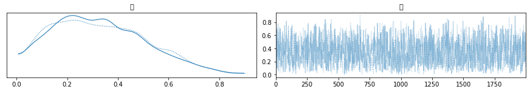

Or maybe we want a `summary` table for the trace, similar to Pandas `pd.DataFrame().describe()`

```
az.summary(trace)
```

|  | mean | sd | hdi_3% | hdi_97% | mcse_mean | mcse_sd | ess_bulk | ess_tail | r_hat |
| --- | --- | --- | --- | --- | --- | --- | --- | --- | --- |
| 𝜃 | 0.33 | 0.181 | 0.016 | 0.642 | 0.005 | 0.003 | 1563.0 | 2202.0 | 1.0 |

Maybe we want to observe the aforementioned information in a different form, seen by arviZ's `plot_posterior` of the trace object

```
az.plot_posterior(trace)
```

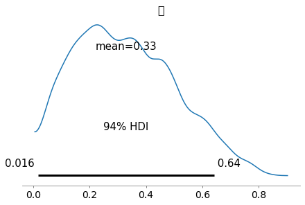

## A summary

So, we went through the following:

- What is Bayesian Modeling?
- Brief Introduction to Probability
- Getting Started with PyMC3

However, there is so much more to learn about PyMC3! In the meantime, you can learn more about PyMC3 via their documentation...

or wait for another exciting [BAyPIGgies Meetup](https://www.meetup.com/BAyPIGgies)! (S/O to Jeff Fischer & team)

## With that being said

## Thank you,

[figure not shown]

## Resources

- [Introduction to PyMC3 by Tung N. Nguyen](https://towardsdatascience.com/introduction-to-pymc3-a-python-package-for-probabilistic-programming-5299278b428)
- [PyMC3 Documentation](https://docs.pymc.io/)
- [Arviz Documentation](https://arviz-devs.github.io/arviz/index.html)
- **For consulting services**: There is a consultancy group called [PyMC3 Labs](https://www.pymc-labs.io/)
  - PyMC3 labs to help answer tough Business questions that require leveraging Bayesian Modeling.